# index.Rmd

### Is there a difference between harder styles music?

In this project I'm going to study the harder styles music in order to justify it's (many) subgenres.

To start the project. There needs to be some grounded evidence that Spotify API is able to distinguish between harder styles and general pop music. So the first steps I took was look at the spotify variables that were unusual or interesting to look at.

```r
library(spotifyr)
library(tidyverse)
```

```r
library(ggplot2)
library(dplyr)
```

Now to load the playlists

```r
# Loading the playlists
hardstyle = get_playlist_audio_features('','3bGSAHGYFEDxyEj7uXe0qq')
hardcore = get_playlist_audio_features('','1tey17jGZg2tp6woRxvolN')
frenchcore = get_playlist_audio_features('', '5MryWieIAaH531t2tY7JCm')
rawstyle = get_playlist_audio_features('','1d4FuT80Z9iUyCiwemB7g6')
terrorcore = get_playlist_audio_features('', '7tbu00WFTZ1g6a2iiTymJX')
happy_hardcore = get_playlist_audio_features('','3Nt4zu8d9DN75ltGEPrpu8')
apres_ski = get_playlist_audio_features('', '0TCZJuWGr8NVrfy1IZpwvk')

# Control with 'normal' music
top50 = get_playlist_audio_features('', '79PP1evdXDE0F7mfYRY2wZ')
```

Combine the factors into one dataset

```r
combi <- bind_rows(
  hardstyle %>% mutate(category = 'Hardstyle'),
  hardcore %>% mutate(category = 'Hardcore'),
  frenchcore %>% mutate(category = 'Frenchcore'),
  rawstyle %>% mutate(category = 'Rawstyle'),
  terrorcore %>% mutate(category = 'Terrorcore'),
  happy_hardcore %>% mutate(category = 'Happy hardcore'),
  apres_ski %>% mutate(category = 'Apres Ski'),
  top50 %>% mutate(category = 'Top 50 (control)')
)
```

## Harder styles, energy

The harder styles music is to some people quite overwhelming. A 'wall of sound' is how this music is often described. So it would be interesting to see the energy associated with harder styles music.

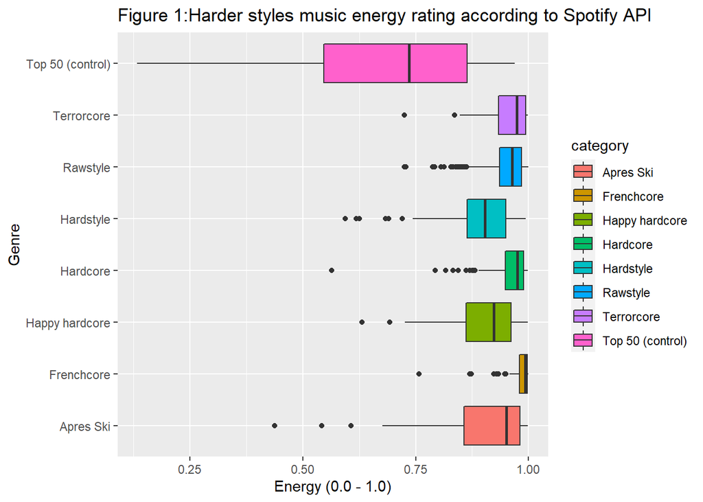

```r
ggplot(
  # Compare harder style genres in terms of
  combi, aes(x = energy, fill = category)
  ) +
  # Boxplot of each genre and it's energy rating
  geom_boxplot (aes(energy, category)) +

  # Set axis labels
  labs(x = 'Energy (0.0 - 1.0)', y = 'Genre') +

  # Set title
  ggtitle('Figure 1:Harder styles music energy rating according to Spotify API')
```

```r
  # TODO: Set theme
```

Figure 1 shows that harder styles music does live up to its reputation in this case having a high energy rating associated with fast, loud and entropic music. Rougly speaking there are three camps of intensity. - High energy: Hardstyle, Happy Hardcore and Apres ski. - Very high energy: Terrorcore, Rawstyle, Harcore - Extreme energy: Frenchcore

## Comparing subgenres on loudness and energy

Energy is dependent on how fast, loud and entropic a track is. So the next interesting thing to discover is how the relationship between loudness and energy is and how the subgenres score in comparison to eachother.

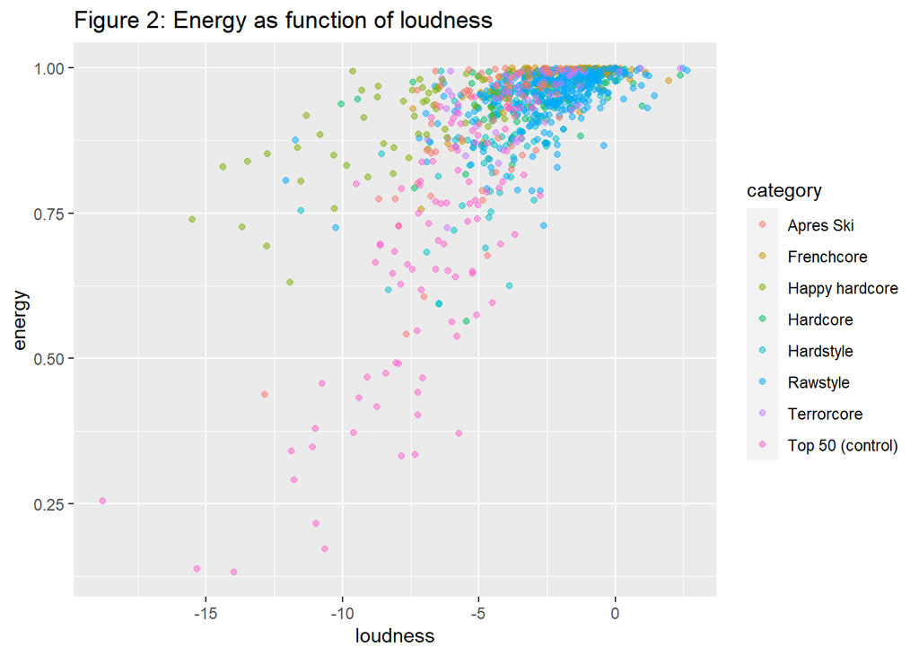

```r
ggplot(
  # Compare BPM vs energy level
  combi, aes(x = loudness, y = energy, color = category)
) +

  # Jittery scatterplot
  geom_jitter(alpha = 0.5) +

  # title
  ggtitle('Figure 2: Energy as function of loudness')
```

Energy seems to positively correlate with loudness

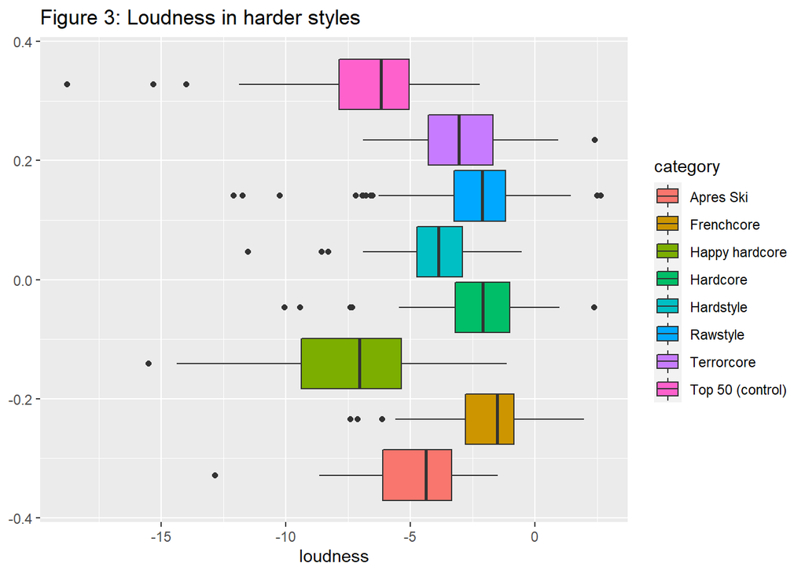

```r
ggplot(
  combi %>%
    group_by(category),
  aes(x = loudness, fill = category)
) +

  # Plot comparing loudness
  geom_boxplot(bins = 30) +

  # Title
  ggtitle('Figure 3: Loudness in harder styles')
```

Figure 3: happy hardcore is one of the more 'soft' harder styles. T Fun fact is that this genre is from the late 80s and early 90s. In line with the trend of music becoming louder. For all the other harder styles genres are from later (late 90s and 00s)

I'm not sure what I want with this figure yet. I guess it's something that could classify harder styles, but I feel like there could be a better figure.

TODO: - Continue developing the profiles of each harder style - Focus on individual numbers of different genres to try and define them. - Look at the artists. - Improve the figures (definitely)